# Midpoint Deliverable

Keith Ellingwood, Sage Choi, Audrey Kho, Faduma Edey

2/24/2020

## The Problem

For our project, we wanted to explore the field of environmental trends. All of our group members are concerned about environmental trends that we are seeing, especially because climate change seems to already have reached such an advanced stage while people in authority mostly continue to remain unbothered by it. We wanted to use data to learn more about it while also educating others about what exactly is happening with our planet’s environment. By answering some of the questions we were curious about, we hope to contribute to the solution to this extremely urgent problem. One particular issue we were all concerned about is the effects of climate change, and what factors may be contributing to it.

## Summary Information

Our dataset we are using is information on **pollution in the United States** from the years **2000-2016**. The data comes from *kaggle.com*, and was sourced from the Harvard Database and hosted on the WorldFish Dataverse under Harvard Dataverse. There are **29** columns and **1746661** rows in the data. The data contains lots of information about the locations in which the readings were taken, and includes things like **Address, State, County, City, Date Local**. There are **144** different cities in the US accounted for in this dataset. It focuses on 4 main types of greenhouse gasses: **NO2, O3, SO2, CO**.

## Table

Here, we have a table of our data aggregated by State and sorted from highest total emmissions to lowest. Each state contains the amount of each major pollutant we are looking at total for the years 2000-2016, as well as all of the pollutatnts totaled (in parts per billion notation). We included this so we could see a breakdown of exactly which states in the US are the biggest culprits for high emmissions, and to also see which pollutants were higher in which states. From the chart, we can see that **California** has the highest total emissions for all pollutants in the US, clocking in at **281,350,906.5** PPB total. Contrary to that, we can see that **Washington** actually has the lowest total emmissions, at **227,664.4** PPB total. This is suprising because we expected **Rhode Island** to be the lowest since it is the state with the smallest amount of landmass.

| State | Total CO | Total NO2 | Total O3 | Total SO2 | Total Emmissions |
| --- | --- | --- | --- | --- | --- |
| California | 257814656.3 | 7865429.298 | 15010161.59 | 660659.3046 | 281350906.5 |
| Pennsylvania | 45634776.2 | 2345420.728 | 4991558.88 | 763426.2926 | 53735182.2 |
| Arizona | 34264618.3 | 1331707.386 | 1745251.10 | 95276.6298 | 37436853.4 |
| Texas | 30550333.3 | 1428275.707 | 3174726.60 | 121694.0795 | 35275029.7 |
| New York | 25155085.4 | 1303179.357 | 1666327.14 | 328574.0492 | 28453165.9 |
| Illinois | 19683526.8 | 780215.601 | 1135580.30 | 134464.3035 | 21733787.0 |
| District Of Columbia | 20304207.9 | 454545.961 | 621438.49 | 108171.6703 | 21488364.0 |
| Colorado | 15592236.0 | 690890.851 | 828725.84 | 53050.6309 | 17164903.3 |
| Arkansas | 14923978.5 | 344617.781 | 924590.42 | 48874.8309 | 16242061.5 |
| Virginia | 13588486.0 | 383634.404 | 1016211.99 | 108598.3735 | 15096930.8 |
| North Carolina | 13173258.3 | 391794.154 | 1083913.21 | 54311.4807 | 14703277.1 |
| Kansas | 12864733.6 | 349087.388 | 818543.83 | 74552.4454 | 14106917.2 |
| New Jersey | 10758292.5 | 497105.286 | 629899.93 | 83271.7037 | 11968569.4 |
| Florida | 11021759.0 | 190844.246 | 694577.25 | 12842.1076 | 11920022.6 |
| Louisiana | 9844380.3 | 328455.509 | 557526.08 | 55993.9654 | 10786355.9 |
| Missouri | 9237361.1 | 295899.321 | 549559.64 | 68182.3503 | 10151002.4 |
| Connecticut | 7509172.3 | 269126.554 | 865663.88 | 27302.5108 | 8671265.3 |
| Country Of Mexico | 8113396.7 | 193274.380 | 208345.08 | 18496.5374 | 8533512.7 |
| Hawaii | 7450970.7 | 64167.391 | 510118.64 | 19991.1314 | 8045247.9 |
| Massachusetts | 6869335.0 | 402244.854 | 445837.12 | 55255.2821 | 7772672.2 |
| Maryland | 6622624.8 | 234814.183 | 625770.04 | 39119.3248 | 7522328.4 |
| Ohio | 6204428.0 | 277818.274 | 566229.62 | 62998.5193 | 7111474.4 |
| Iowa | 5612422.0 | 175456.824 | 720312.31 | 10532.6501 | 6518723.8 |
| Oklahoma | 4831601.6 | 232787.256 | 1079825.27 | 24826.2629 | 6169040.4 |
| Maine | 5337022.2 | 121346.273 | 591496.96 | 22113.7629 | 6071979.2 |
| Indiana | 4972850.7 | 168775.835 | 409680.18 | 43147.2058 | 5594453.9 |
| Oregon | 3602550.4 | 113819.164 | 227165.95 | 11544.0001 | 3955079.5 |
| New Hampshire | 3199517.9 | 68750.579 | 259749.17 | 13162.9908 | 3541180.6 |
| Utah | 3068566.8 | 114282.777 | 278013.66 | 3484.7304 | 3464348.0 |
| Michigan | 2851245.6 | 137541.550 | 223690.59 | 25447.8636 | 3237925.6 |
| Kentucky | 2415766.4 | 176076.955 | 427193.59 | 55160.4319 | 3074197.4 |
| Tennessee | 2560581.4 | 9912.537 | 220809.37 | 4799.5215 | 2796102.8 |
| Georgia | 2482629.2 | 86692.852 | 159017.46 | 3743.8824 | 2732083.4 |
| Nevada | 2145275.6 | 116807.507 | 310719.99 | 3311.1143 | 2576114.2 |
| North Dakota | 1856140.0 | 52819.691 | 285302.08 | 2429.5093 | 2196691.3 |
| Wyoming | 1409450.1 | 42966.190 | 496690.82 | 4442.9952 | 1953550.1 |
| New Mexico | 1504331.8 | 88016.600 | 226011.91 | 4369.0725 | 1822729.4 |
| South Dakota | 1513346.0 | 42195.171 | 249788.89 | 3958.3158 | 1809288.3 |
| Rhode Island | 1417006.0 | 45195.114 | 190204.46 | 3272.7729 | 1655678.3 |
| Delaware | 949607.9 | 42052.726 | 96174.69 | 3681.6973 | 1091517.0 |
| South Carolina | 814410.0 | 12675.981 | 207032.96 | 5395.4103 | 1039514.4 |
| Minnesota | 871140.3 | 24263.509 | 96102.91 | 2415.8389 | 993922.5 |
| Alaska | 835866.1 | 22332.161 | 25265.29 | 12009.3322 | 895472.9 |
| Alabama | 664608.6 | 29417.825 | 76935.61 | 3233.0231 | 774195.0 |
| Wisconsin | 531247.3 | 22692.597 | 34007.18 | 3964.1579 | 591911.2 |
| Idaho | 325654.3 | 16320.730 | 49389.00 | 596.6795 | 391960.7 |
| Washington | 196995.4 | 9817.304 | 20111.26 | 740.4538 | 227664.4 |

## Charts

### Chart 1

The line chart below shows the **average yearly emissions levels** of each of the four air pollutants in the dataset: *Carbon Monoxide (CO)*, *Sulfur Dioxide (SO2)*, *Ozone (O3)*, and *Nitrogen Dioxide (NO2)*. The data shown in this chart summarizes the emission levels of these harmful gases from the years 2000-2016 and is intended to show the gases’ emission levels relative to each other. More importantly, this chart shows the changes in the average emission levels of each gas through the years.

As can be seen in the chart, the average *CO* emissions have consistently been the highest by a couple hundred parts per billion throughout the years. The average *O3*, *NO2*, and *SO2* emission levels have been quite close to each other all throughout and saw very slight changes, if any. On the other hand, the line representing the *CO* emissions has clearly been experiencing a downward trend since the year 2000, which is great news for the environment. However, a slight rise can also be observed towards the end of the *CO* emission graph, which could be an indicator of a shift into an upward trend in the following years.

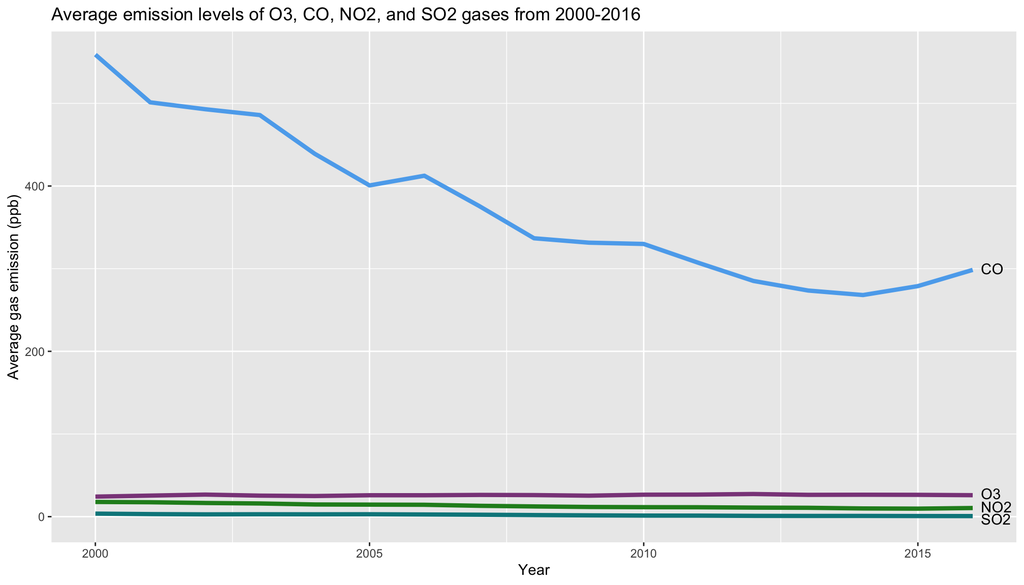

### Chart 2

Chart 2 is a pie chart intended to show the relationship between the averages of **four major pollutants**: Carbon Monoxide **(CO)**, Sulfur Dioxide **(SO2)**, Ozone **(O3)**, and Nitrogen Dioxide **(NO2)** in part per billion.

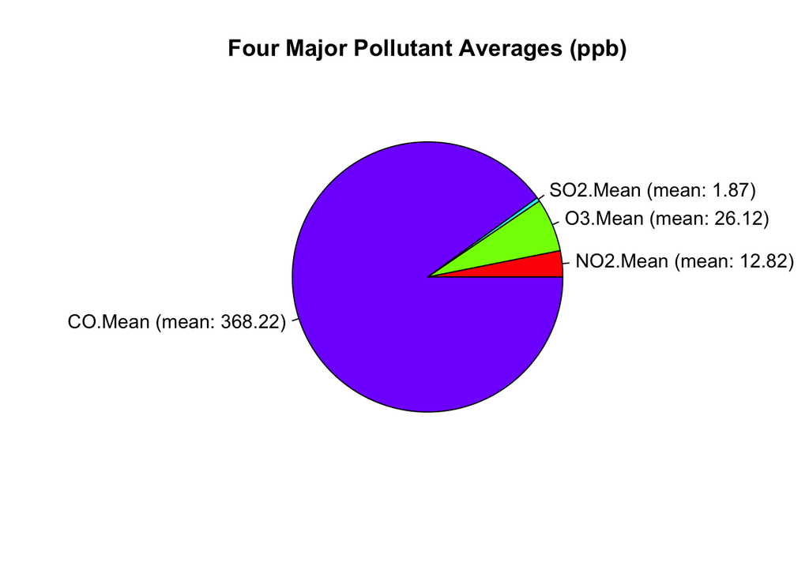